# matias_contador

Matias Contador

16 de octubre de 2019

## Resumen de los datos

```r
summary(df_cuencas)
```

```
##  codigo_estacion       nombre              altura          latitud
##  Min.   : 1020003   Length:1411180     Min.   :   0.0   Min.   :-54.04
##  1st Qu.: 4320001   Class :character   1st Qu.:  45.0   1st Qu.:-37.21
##  Median : 5734001   Mode  :character   Median : 395.0   Median :-33.59
##  Mean   : 6279953                      Mean   : 585.6   Mean   :-33.68
##  3rd Qu.: 8308000                      3rd Qu.: 750.0   3rd Qu.:-29.95
##  Max.   :12876004                      Max.   :4370.0   Max.   :-18.23
##
##     longitud      codigo_cuenca    nombre_sub_cuenca
##  Min.   :-73.28   Min.   : 10.00   Length:1411180
##  1st Qu.:-72.07   1st Qu.: 43.00   Class :character
##  Median :-71.25   Median : 57.00   Mode  :character
##  Mean   :-71.22   Mean   : 62.56
##  3rd Qu.:-70.53   3rd Qu.: 83.00
##  Max.   :-68.14   Max.   :128.00
##
##  cantidad_observaciones     fecha                caudal
##  Min.   :  802          Min.   :1960-01-02   Min.   :    0.00
##  1st Qu.:10255          1st Qu.:1982-12-15   1st Qu.:    1.25
##  Median :14889          Median :1997-01-13   Median :    8.95
##  Mean   :15740          Mean   :1994-08-26   Mean   :   95.52
##  3rd Qu.:20611          3rd Qu.:2007-12-04   3rd Qu.:   69.70
##  Max.   :36667          Max.   :2018-03-09   Max.   :15805.00
##
##     gauge_id        precip_promedio   temp_max_promedio    season
##  Min.   : 1020003   Min.   :  0.000   Min.   :-19.05    Fall  :353152
##  1st Qu.: 4320001   1st Qu.:  0.000   1st Qu.: 13.70    Winter:354651
##  Median : 5734001   Median :  0.000   Median : 19.08    Spring:353313
##  Mean   : 6279953   Mean   :  1.921   Mean   : 19.21    Summer:350064
##  3rd Qu.: 8308000   3rd Qu.:  0.000   3rd Qu.: 25.20
##  Max.   :12876004   Max.   :258.600   Max.   : 41.50
##                     NA's   :27767     NA's   :151563
##  caudal_extremo     temp_extremo    precip_extremo
##  Min.   :0.00000   Min.   :0.00     Min.   :0.000
##  1st Qu.:0.00000   1st Qu.:0.00     1st Qu.:0.000
##  Median :0.00000   Median :0.00     Median :0.000
##  Mean   :0.04981   Mean   :0.05     Mean   :0.044
##  3rd Qu.:0.00000   3rd Qu.:0.00     3rd Qu.:0.000
##  Max.   :1.00000   Max.   :1.00     Max.   :1.000
##                    NA's   :151563   NA's   :27767
```

## Mising

Del summary se puede notar que las siguientes variables tiene valores NA  
Pprecip_promedio = 27.767 observaciones -> (1.9% de los dias de medicion por cuenca)  
temp_max_promedio = 151.563 observaciones -> (10.7% de los dias de medicion por cuenca)

#### Estaciones con Datos NA

| Total Estaciones | Estaciones con Precipitacion Promedio NA | Estaciones con Temp Max Na |
| --- | --- | --- |
| 133 | 48 | 109 |

Se puede notar que gran porcentaje de las estaciones tienen datos NA. Esto se puede deber por varios motivos por lo que haremos un doble click.

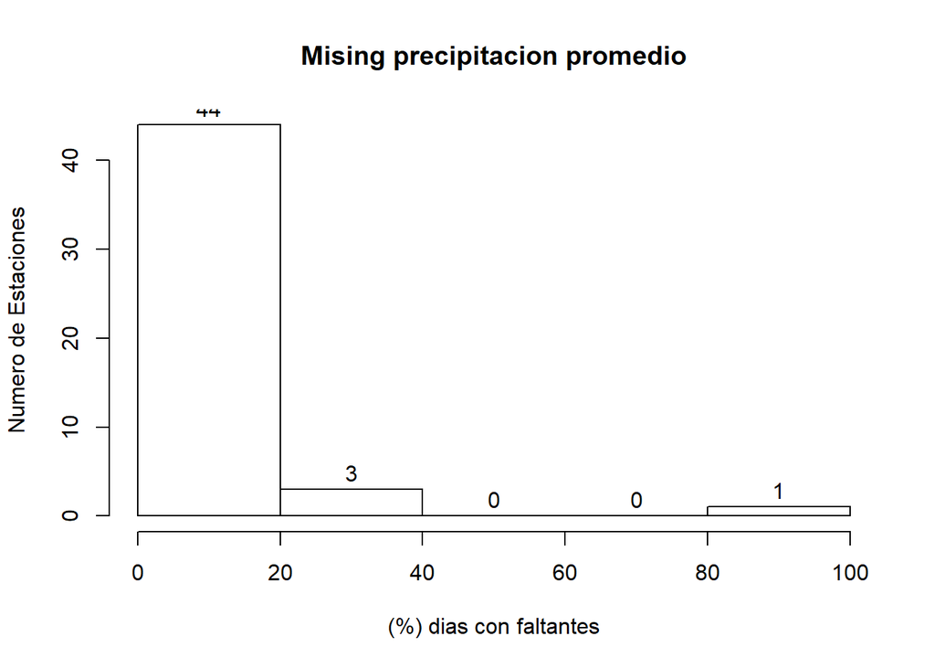

Gran porcentaje de las estaciones con faltantes en precipitacion promedio tienen menos de un 20% de datos con NA en esta variable. En estos casos se puede creer que hay dias que no se realizan mediciones. Por ejemplo mantencion de instrumentos, se olvido medir, se omite porque no llueve etc.

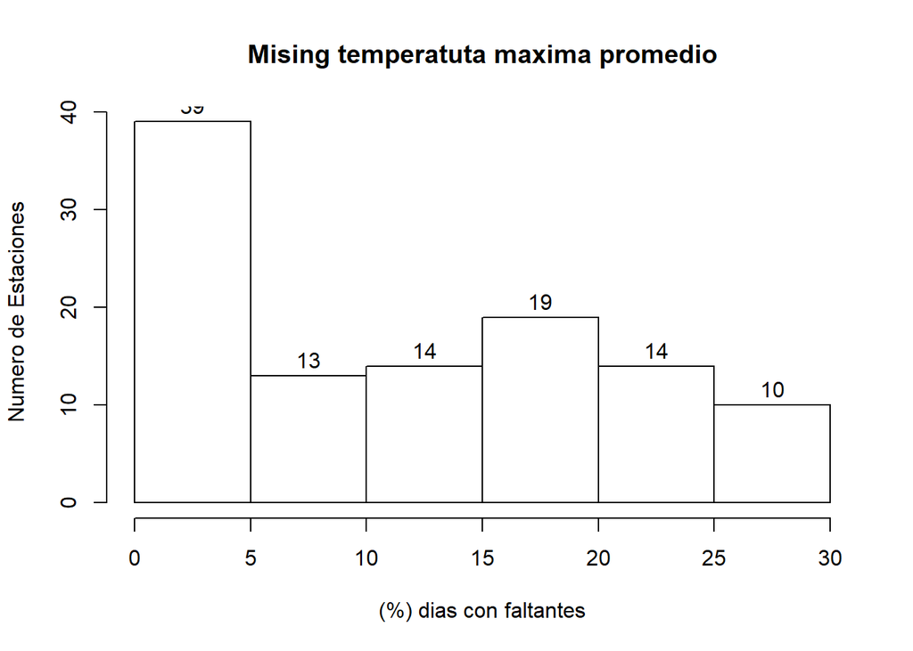

Para la variable temp_max_promedio tenemos un mayor porcentaje con menos de un 5% de dias con NA, el resto se distribuye equitativamente entre 5% y 30%. Aqui tambien se podria creer que es debido a olvidos o conseguir los intstrumentos luego de que se empesara a medir el caudal.

Hay que recalcar que la explicaciones de datos NA son teorias sin conocer el negocio ni de los metodos de medicion. Para tener mejor certesa, habria que preguntar a quienes trabajan en esta empresa por que se deben estos faltantes.

## Graficos dentro del caudal

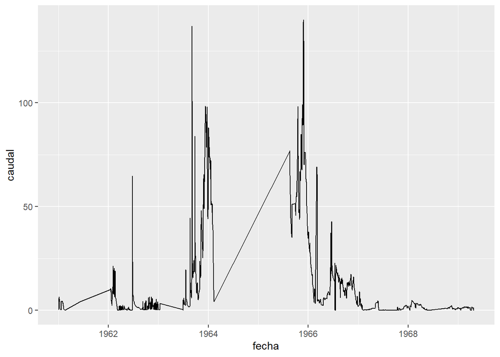

En el chunk grafico_una_estacion puede cambiar los inputs codigo_estacion_var, fecha_min, fecha_max para tener otros resultados

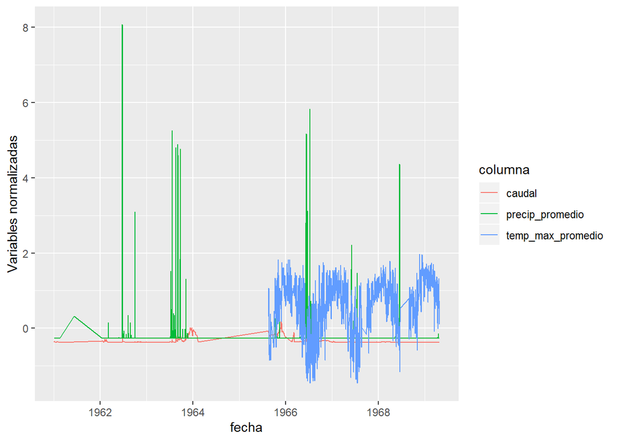

En el chunk grafico_una_estacion_varios puede cambiar los inputs codigo_estacion_var, fecha_min, fecha_max para tener otros resultados

## Data Frame para el analisis

|  | codigo_estacion | nombre | altura | latitud | longitud | codigo_cuenca | nombre_sub_cuenca | cantidad_observaciones | fecha | caudal | gauge_id | precip_promedio | temp_max_promedio | season | caudal_extremo | temp_extremo | precip_extremo |
| --- | --- | --- | --- | --- | --- | --- | --- | --- | --- | --- | --- | --- | --- | --- | --- | --- | --- |
| 1 | 4540001 | Rio Grande En Paloma 1 | 310 | -30.6833000183105 | -71.0500030517578 | 45 | Rio Grande Bajo (Entre E Paloma Y Rio Hurtado) | 11575 | 1960-01-06 | 0.812 | 4540001 | 0 |  | Summer | 0 |  | 0 |
| 2 | 4540001 | Rio Grande En Paloma 1 | 310 | -30.6833000183105 | -71.0500030517578 | 45 | Rio Grande Bajo (Entre E Paloma Y Rio Hurtado) | 11575 | 1961-01-14 | 0.652 | 4540001 | 0 |  | Summer | 0 |  | 0 |
| 3 | 4540001 | Rio Grande En Paloma 1 | 310 | -30.6833000183105 | -71.0500030517578 | 45 | Rio Grande Bajo (Entre E Paloma Y Rio Hurtado) | 11575 | 1961-01-28 | 4.3 | 4540001 | 0 |  | Summer | 0 |  | 0 |
| 4 | 4540001 | Rio Grande En Paloma 1 | 310 | -30.6833000183105 | -71.0500030517578 | 45 | Rio Grande Bajo (Entre E Paloma Y Rio Hurtado) | 11575 | 1963-12-24 | 94.9 | 4540001 | 0 |  | Summer | 1 |  | 0 |
| 5 | 4540001 | Rio Grande En Paloma 1 | 310 | -30.6833000183105 | -71.0500030517578 | 45 | Rio Grande Bajo (Entre E Paloma Y Rio Hurtado) | 11575 | 1963-12-25 | 98.1 | 4540001 | 0 |  | Summer | 1 |  | 0 |
| 6 | 4540001 | Rio Grande En Paloma 1 | 310 | -30.6833000183105 | -71.0500030517578 | 45 | Rio Grande Bajo (Entre E Paloma Y Rio Hurtado) | 11575 | 1964-02-07 | 23 | 4540001 | 0 |  | Summer | 0 |  | 0 |
| 7 | 4540001 | Rio Grande En Paloma 1 | 310 | -30.6833000183105 | -71.0500030517578 | 45 | Rio Grande Bajo (Entre E Paloma Y Rio Hurtado) | 11575 | 1965-12-21 | 50.4 | 4540001 | 0 | 28.5 | Summer | 1 | 0 | 0 |
| 8 | 4540001 | Rio Grande En Paloma 1 | 310 | -30.6833000183105 | -71.0500030517578 | 45 | Rio Grande Bajo (Entre E Paloma Y Rio Hurtado) | 11575 | 1966-02-04 | 11.8 | 4540001 | 0 | 25 | Summer | 0 | 0 | 0 |
| 9 | 4540001 | Rio Grande En Paloma 1 | 310 | -30.6833000183105 | -71.0500030517578 | 45 | Rio Grande Bajo (Entre E Paloma Y Rio Hurtado) | 11575 | 1967-03-15 | 0.485 | 4540001 | 0 | 20 | Summer | 0 | 0 | 0 |
| 10 | 4540001 | Rio Grande En Paloma 1 | 310 | -30.6833000183105 | -71.0500030517578 | 45 | Rio Grande Bajo (Entre E Paloma Y Rio Hurtado) | 11575 | 1968-01-11 | 0.839 | 4540001 | 0 | 26 | Summer | 0 | 0 | 0 |

[output cut: 90 more lines]

Se agregan las columnas caudal_extremo, temp_extremo, precip_extremo con valor 1 si la variable esta por sobre el 95% de las demas. Esta toma en cuenta la estacionalidad, pues, por ejemplo, una temperatura de 25 grados en invierno puede ser extrema, pero en verano es normal. Tambien toma en cuenta que cada cuenca (o estacion) es diferente. Lo que es extremo para una cuenca no lo es para la otra.

Es bastante razonable medir condiciones extremas, ya que son las que causan los problemas en la sociedad y medio ambiente. Poder predecir estos eventos nos ayuda a evitar problemas. Sin embargo tomar un percentil es un metodo con oportunidades de mejora ya que ignora la distribucion de los datos. Supongamo alguna estacion que tiene muy poca variacion en sus variables. Escoger el percentil 95 de sus datos indicara que tiene valores extremos a valores totalmente comunes.

Otros metodos comunes para omitir valores extremos:

1. Tener un rango entre la media y dos o tres desviaciones estandar
2. Tener un rango entre la mediana y 1,5 rangos intercuartiles

## Caudal Extremo

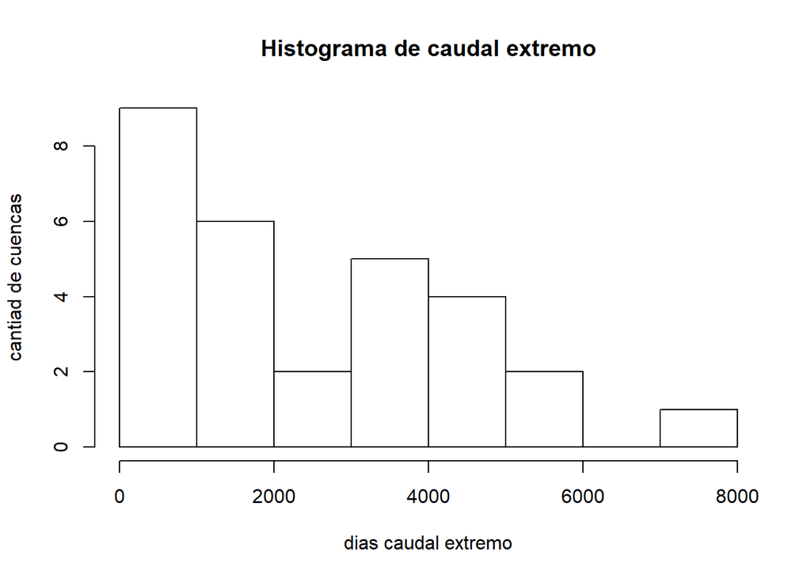

Del histograma se puede inferir que han habido una gran diferencia en cuanto a dias extremos entre las distintas cuencas. Hay que notar que estas cuencas pueden tener distintos periodos de tiempo de medicion por lo que es importante ver cuantos dias extremos se tiene anualmente por estacion.

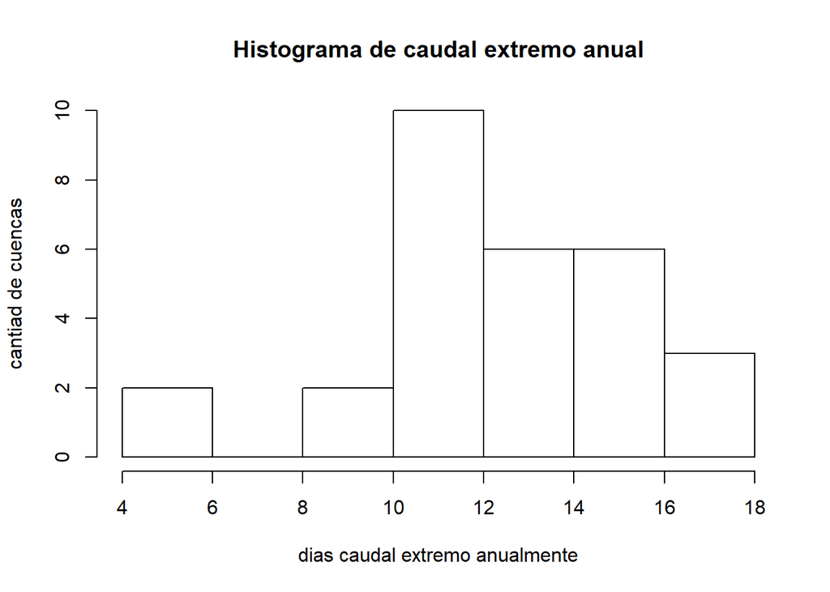

La gran mayoria de las cuencas tiene entre 10 y 16 dias de caudal extremo por estacion. Solo un par de cuencas muestran tener entre 4 y 6 dias de caudal extremo por estacion.

## Variables extremas

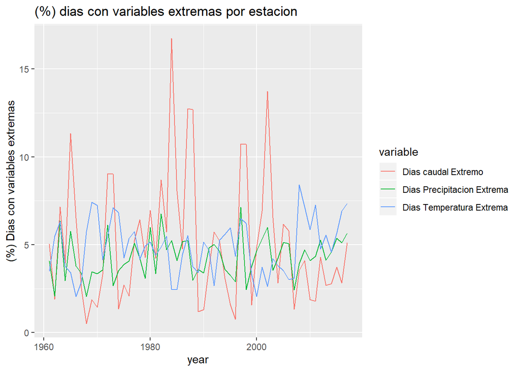

De este grafico se puede inferir que hay una gran varianza anualmente. Los porcentajes de dias con variable extrema se encuentra alrededor del 5% por la definicion que dimos a valores extremos. Es dificil notar si es que las variables extremas van aumentando o disminuyendo por lo que se graficara por decada.

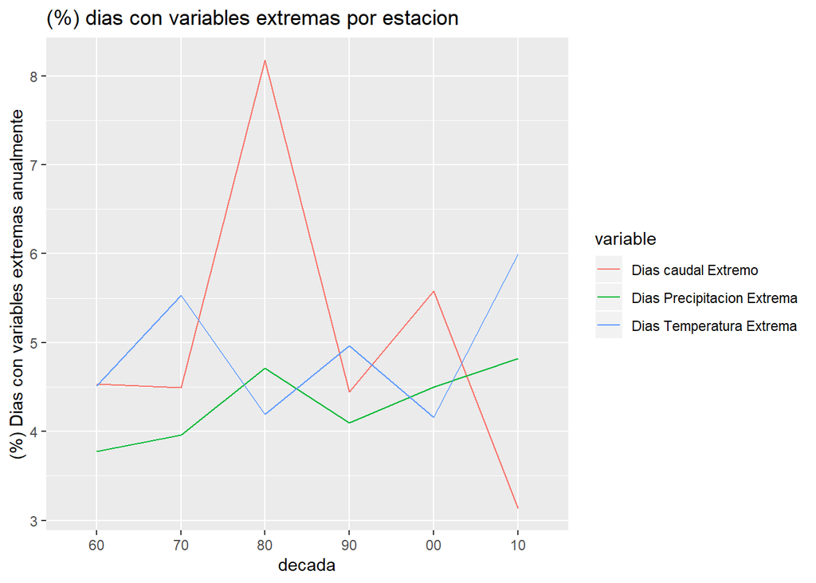

## Prediccion

En el siguiente link https://encyclopedia.pub/73 encontramos una publicacion con distintos metodos de ML para predecir este tipo de eventos. Probaremos con SVM el cual indica que sirve para predecir sucesos tanto en largo como corto plazo.

## Matriz de correlacion

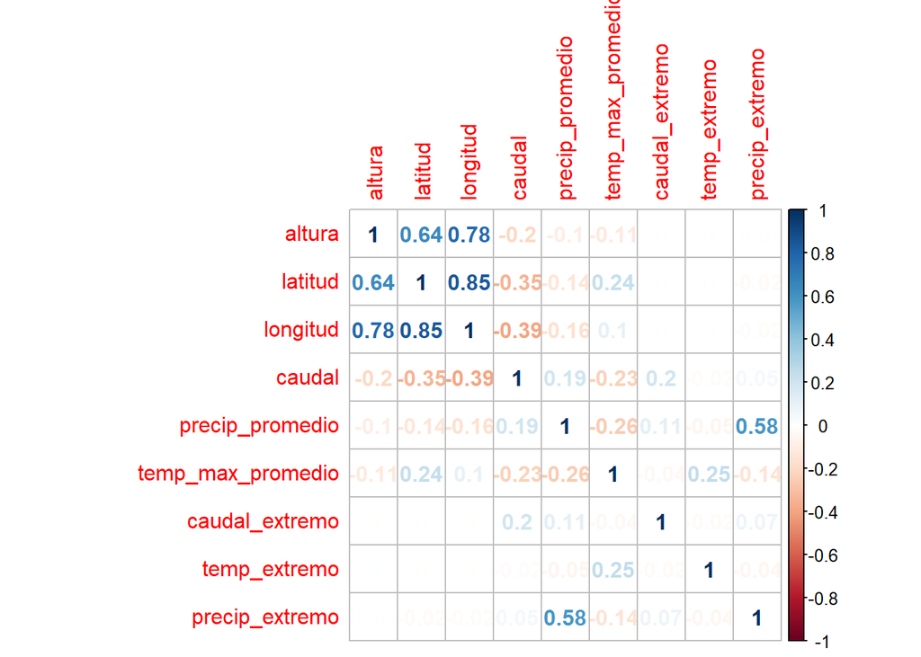

Lamentablemente el modelo no se pudo correr localmente pero se deja el archivo modelo ml adjunto para poder revisar.

Por motivos de tiempo no se pueden revisar todos los metodos propuestos. Para llegar a una respuesta mas robusta corresponderia revisar los distintos metodos propuestos por el autor y elegir el modelo con menor error.